# Introduction to Anomaly Detection

# Sklearn Methods

### Density-based spatial clustering of applications with noise (DBSCAN) - Unsupervised Learning

It is a density-based clustering non-parametric algorithm: given a set of points in some space, it groups together points that are closely packed together (points with many nearby neighbors), marking as outliers points that lie alone in low-density regions (whose nearest neighbors are too far away).

Два параметра, которые задаются: Какое минимальное количество точек данных необходимо для определения одного кластера? - MinPts Как далеко может быть одна точка от следующей точки в том же кластере? - Eps

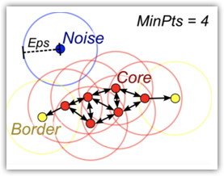

```python
Image("img/dbscan_fig.png")
```

```python
#Set the estimated percentage of  outliers
my_percentage = 0.03

# to begin with, we consider all observations to be anomalous
outlier_percentage = 1.

num_clusters = []
anomaly_percentage = []

# take a small epsilon and start increasing
eps = 0.01
eps_history = [eps]
while outlier_percentage>my_percentage:
    model = DBSCAN(eps=eps).fit(scaled_data)
    labels = model.labels_
    num_clusters.append(len(np.unique(labels))-1)
    labels = np.array([1 if label == -1 else 0 for label in labels])
    # calculate the current percentage of "noise"
    outlier_percentage = sum(labels==1) / len(labels)
    eps += 0.05
    eps_history.append(eps)
    anomaly_percentage.append(outlier_percentage)

model = DBSCAN(eps)
model.fit(scaled_data)
density_outlier = np.array([1 if label == -1 else 0 for label in model.labels_])
print('eps=', eps)
```

```
eps= 0.16000000000000003
```

```python
anomalies_report(density_outlier)
```

```
Total number of outliers: 66
Percentage of outliers:           0.66%
```

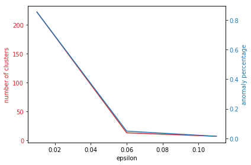

```python
iterations = eps_history[:-1]

fig, ax1 = plt.subplots()

color = 'tab:red'
ax1.set_xlabel('epsilon')
ax1.set_ylabel('number of clusters', color=color)
ax1.plot(iterations, num_clusters, color=color)
ax1.tick_params(axis='y', labelcolor=color)

ax2 = ax1.twinx()  # instantiate a second axes that shares the same x-axis

color = 'tab:blue'
ax2.set_ylabel('anomaly percentage', color=color)  # we already handled the x-label with ax1
ax2.plot(iterations, anomaly_percentage, color=color)
ax2.tick_params(axis='y', labelcolor=color)

fig.tight_layout()  # otherwise the right y-label is slightly clipped
plt.show()
```

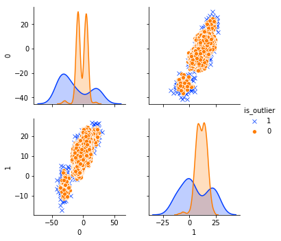

```python
labeled_data = data_features.copy()
labeled_data['is_outlier'] = density_outlier

sns.pairplot(data=labeled_data, vars = other_features,
             hue='is_outlier', hue_order=[1, 0],
             markers=['x', 'o'],  palette='bright');
```

#### Visualization of original sample and sample after applying DBSCAN

```
Percentage of Аnomalies: Original - 3.0 %;                           DBSCAN - 0.66 %
```

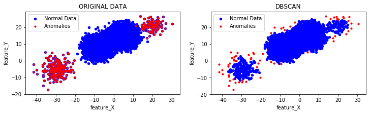

```python
vizualisation_methods(labeled_data, name_method ='DBSCAN')
```

[output not shown]

[figure not shown]

```python
vizualisation_methods(labeled_data, name_method ='DBSCAN')
```

### OneClassSVM

```python
one_class_svm = OneClassSVM(nu=contamination, gamma='auto')
one_class_svm.fit(scaled_data)
svm_outliers = one_class_svm.predict(scaled_data)
svm_outliers = np.array([1 if label == -1 else 0 for label in svm_outliers])

anomalies_report(svm_outliers)
```

```
Total number of outliers: 302
Percentage of outliers:           3.02%
```

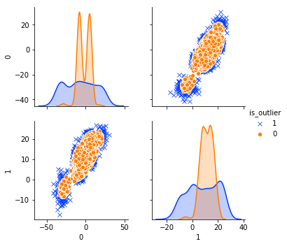

```python
labeled_data = data_features.copy()
labeled_data['is_outlier'] = svm_outliers

sns.pairplot(data=labeled_data, vars = other_features,
             hue='is_outlier', hue_order=[1, 0],
             markers=['x', 'o'],  palette='bright');
```

#### Visualization of original sample and sample after applying OneClassSVM

```
Percentage of Аnomalies: Original - 3.0 %;                           OneClassSVM - 3.02 %
```

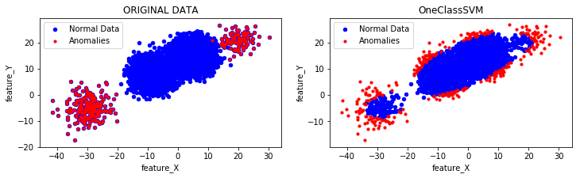

```python
vizualisation_methods(labeled_data, name_method = 'OneClassSVM')
```

### IsolationForest

```python
isolation_forest = IsolationForest(n_estimators=100, contamination=contamination,
                                   max_features=1.0, bootstrap=True, behaviour="new")
isolation_forest.fit(scaled_data)

isolation_outliers = isolation_forest.predict(scaled_data)
isolation_outliers = np.array([1 if label == -1 else 0 for label in isolation_outliers])

anomalies_report(isolation_outliers)
```

```
Total number of outliers: 300
Percentage of outliers:           3.00%
```

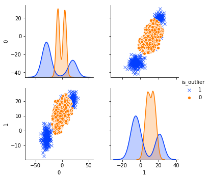

```python
labeled_data = data_features.copy()
labeled_data['is_outlier'] = isolation_outliers

sns.pairplot(data=labeled_data, vars = other_features,
             hue='is_outlier', hue_order=[1, 0],
             markers=['x', 'o'],  palette='bright');
```

#### Visualization of original sample and sample after applying IsolationForest

```
Percentage of Аnomalies: Original - 3.0 %;                           IsolationForest - 3.00 %
```

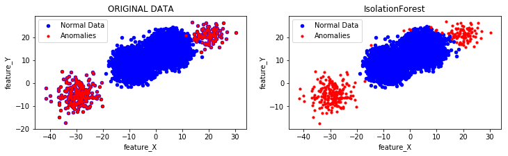

```python
vizualisation_methods(labeled_data, name_method ='IsolationForest')
```

### LocalOutlierFactor

```python
local_outlier_factor = LocalOutlierFactor(n_neighbors=300, contamination=contamination, novelty=False)
local_outlier_factor.fit(scaled_data)

local_factor_outliers = local_outlier_factor.fit_predict(scaled_data)
local_factor_outliers = np.array([1 if label == -1 else 0 for label in local_factor_outliers])

anomalies_report(local_factor_outliers)
```

```
Total number of outliers: 300
Percentage of outliers:           3.00%
```

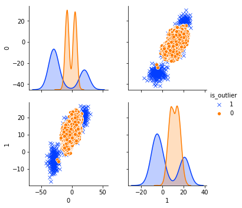

```python
labeled_data = data_features.copy()
labeled_data['is_outlier'] = local_factor_outliers

sns.pairplot(data=labeled_data, vars = other_features,
             hue='is_outlier', hue_order=[1, 0],
             markers=['x', 'o'],  palette='bright');
```

#### Visualization of original sample and sample after applying LocalOutlierFactor

```
Процент выбросов: Original - 3.0 %;                           LocalOutlierFactor - 3.00 %
```

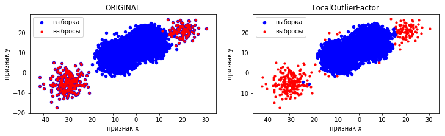

```python
vizualisation_methods(labeled_data, name_method ='LocalOutlierFactor')
```

### EllipticEnvelope

```python
elliptic_envelope = EllipticEnvelope(store_precision=True, assume_centered=False, support_fraction=None, contamination=contamination,
                       random_state=None)
elliptic_envelope.fit(scaled_data)
elliptic_envelope_outliers = elliptic_envelope.predict(scaled_data)
elliptic_envelope_outliers = np.array([1 if label == -1 else 0 for label in elliptic_envelope_outliers])
anomalies_report(elliptic_envelope_outliers)
```

```
Total number of outliers: 300
Percentage of outliers:           3.00%
```

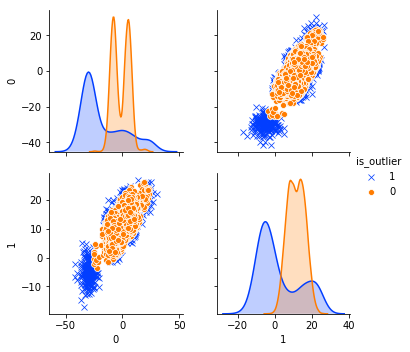

```python
labeled_data = data_features.copy()
labeled_data['is_outlier'] = elliptic_envelope_outliers

sns.pairplot(data=labeled_data, vars = other_features,
             hue='is_outlier', hue_order=[1, 0],
             markers=['x', 'o'],  palette='bright');
```

#### Visualization of original sample and sample after applying EllipticEnvelope

```
Процент выбросов: Original - 3.0 %;                           EllipticEnvelope - 3.00 %
```

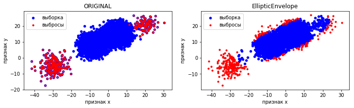

```python
vizualisation_methods(labeled_data, name_method ='EllipticEnvelope')
```

# PyOD Methods

### KNN

```python
n_neighbors = 10
knn = KNN(contamination = contamination, n_neighbors = n_neighbors)
knn.fit(scaled_data)
#knn_outliers = knn.labels_
knn_outliers = knn.predict(scaled_data)
knn_outliers = np.array([1 if label == 1 else 0 for label in knn_outliers])
anomalies_report(knn_outliers)
```

```
Total number of outliers: 264
Percentage of outliers:           2.64%
```

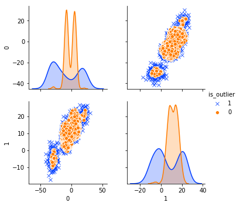

```python
labeled_data = data_features.copy()
labeled_data['is_outlier'] = knn_outliers

sns.pairplot(data=labeled_data, vars = other_features,
             hue='is_outlier', hue_order=[1, 0],
             markers=['x', 'o'],  palette='bright');
```

```
Процент выбросов: Original - 3.0 %;                           KNN - 2.64 %
```

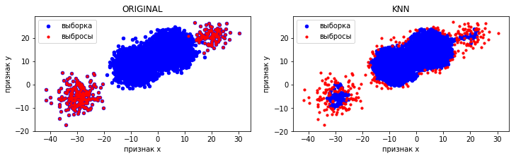

```python
vizualisation_methods(labeled_data, name_method ='KNN')
```

### Cluster-based Local Outlier Factor (CBLOF)

```python
cluster_based_lof = CBLOF(contamination=contamination, check_estimator=False, random_state=42)
cluster_based_lof.fit(scaled_data)
cluster_based_lof_outliers = cluster_based_lof.predict(scaled_data)
cluster_based_lof_outliers = np.array([1 if label == 1 else 0 for label in cluster_based_lof_outliers])
anomalies_report(cluster_based_lof_outliers)
```

```
Total number of outliers: 300
Percentage of outliers:           3.00%
```

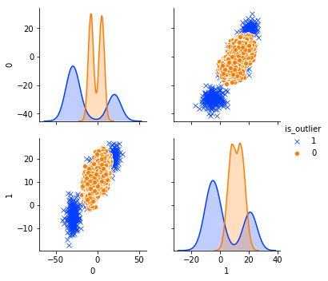

```python
labeled_data = data_features.copy()
labeled_data['is_outlier'] = cluster_based_lof_outliers

sns.pairplot(data=labeled_data, vars = other_features,
             hue='is_outlier', hue_order=[1, 0],
             markers=['x', 'o'],  palette='bright');
```

```
Процент выбросов: Original - 3.0 %;                           Cluster-based Local Outlier Factor - 3.00 %
```

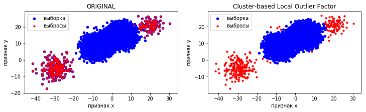

```python
vizualisation_methods(labeled_data, name_method ='Cluster-based Local Outlier Factor')
```

### Histogram-base Outlier Detection (HBOS)

```python
histogram_base = HBOS(contamination=contamination)
histogram_base.fit(scaled_data)
histogram_base_outliers = histogram_base.predict(scaled_data)
histogram_base_outliers = np.array([1 if label == 1 else 0 for label in histogram_base_outliers])
anomalies_report(histogram_base_outliers)
```

```
Total number of outliers: 278
Percentage of outliers:           2.78%
```

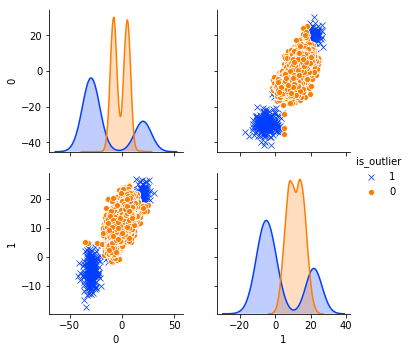

```python
labeled_data = data_features.copy()
labeled_data['is_outlier'] = histogram_base_outliers

sns.pairplot(data=labeled_data, vars = other_features,
             hue='is_outlier', hue_order=[1, 0],
             markers=['x', 'o'],  palette='bright');
```

```
Процент выбросов: Original - 3.0 %;                           Histogram-base Outlier Detection (HBOS) - 2.78 %
```

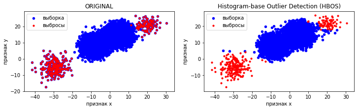

```python
vizualisation_methods(labeled_data, name_method ='Histogram-base Outlier Detection (HBOS)')
```

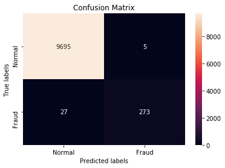

```python
y_pred = histogram_base_outliers
conf_matrix = metrics.confusion_matrix(y,y_pred)

ax=plt.subplot()
sns.heatmap(conf_matrix,annot=True,ax=ax,fmt='g')#annot=True to annotate cells, fmt='g' numbers not scientific form
ax.set_xlabel('Predicted labels'); ax.set_ylabel('True labels')
ax.set_title('Confusion Matrix');
ax.xaxis.set_ticklabels(['Normal', 'Fraud']); ax.yaxis.set_ticklabels(['Normal', 'Fraud']);
ax.set(yticks=[0, 2],
       xticks=[0.5, 1.5])
ax.yaxis.set_major_locator(ticker.IndexLocator(base=1, offset=0.5))
```

### AutoEncoder

```python
epochs = 25
autoencoder = AutoEncoder(epochs=epochs, contamination=contamination, hidden_neurons=[2,1,2] )
autoencoder.fit(scaled_data)

autoencoder_outliers = autoencoder.labels_
autoencoder_outliers = np.array([1 if label == 1 else 0 for label in autoencoder_outliers])
anomalies_report(autoencoder_outliers)
```

```
Model: "sequential_3"
_________________________________________________________________
Layer (type)                 Output Shape              Param #
=================================================================
dense_13 (Dense)             (None, 2)                 6
_________________________________________________________________
dropout_11 (Dropout)         (None, 2)                 0
_________________________________________________________________
dense_14 (Dense)             (None, 2)                 6
_________________________________________________________________
dropout_12 (Dropout)         (None, 2)                 0
_________________________________________________________________
dense_15 (Dense)             (None, 2)                 6
_________________________________________________________________
dropout_13 (Dropout)         (None, 2)                 0
_________________________________________________________________
dense_16 (Dense)             (None, 1)                 3
_________________________________________________________________
dropout_14 (Dropout)         (None, 1)                 0
_________________________________________________________________
dense_17 (Dense)             (None, 2)                 4
_________________________________________________________________
dropout_15 (Dropout)         (None, 2)                 0
_________________________________________________________________
dense_18 (Dense)             (None, 2)                 6
=================================================================
Total params: 31
Trainable params: 31
Non-trainable params: 0
_________________________________________________________________
None
Train on 9000 samples, validate on 1000 samples
Total number of outliers: 300
Percentage of outliers:           3.00%
```

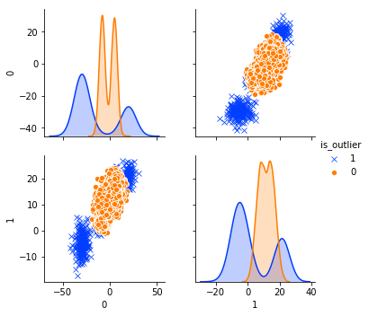

```python
labeled_data = data_features.copy()
labeled_data['is_outlier'] = autoencoder_outliers

sns.pairplot(data=labeled_data, vars = other_features,
             hue='is_outlier', hue_order=[1, 0],
             markers=['x', 'o'],  palette='bright');
```

```
Процент выбросов: Original - 3.0 %;                           Autoencoder - 3.00 %
```

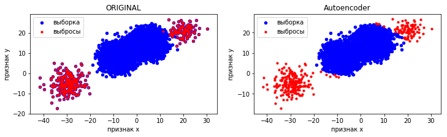

```python
vizualisation_methods(labeled_data, name_method ='Autoencoder')
```

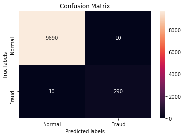

```python
y_pred = autoencoder_outliers
conf_matrix = metrics.confusion_matrix(y,y_pred)

ax=plt.subplot()
sns.heatmap(conf_matrix,annot=True,ax=ax,fmt='g')#annot=True to annotate cells, fmt='g' numbers not scientific form
ax.set_xlabel('Predicted labels'); ax.set_ylabel('True labels')
ax.set_title('Confusion Matrix');
ax.xaxis.set_ticklabels(['Normal', 'Fraud']); ax.yaxis.set_ticklabels(['Normal', 'Fraud']);
ax.set(yticks=[0, 2],
       xticks=[0.5, 1.5])
ax.yaxis.set_major_locator(ticker.IndexLocator(base=1, offset=0.5))
```

```python
y = y.reshape(-1, 1)
y_pred = y_pred.reshape(-1, 1)
```

```python
from sklearn.neighbors import KNeighborsClassifier
knn_model = KNeighborsClassifier(n_neighbors=1)

# Train the model using the training sets
knn_model.fit(y_pred, y)
```

```
KNeighborsClassifier(n_neighbors=1)
```

```python
%%time
knn_predicted= knn_model.predict(autoencoder.labels_.reshape(-1, 1))
```

```
Wall time: 2.09 s
```

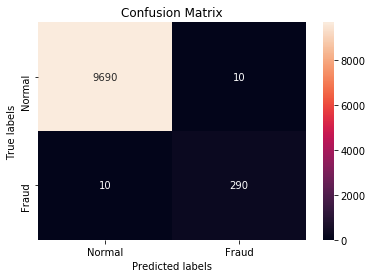

```python
conf_matrix = metrics.confusion_matrix(y,knn_predicted)

ax=plt.subplot()
sns.heatmap(conf_matrix,annot=True,ax=ax,fmt='g')#annot=True to annotate cells, fmt='g' numbers not scientific form
ax.set_xlabel('Predicted labels'); ax.set_ylabel('True labels')
ax.set_title('Confusion Matrix');
ax.xaxis.set_ticklabels(['Normal', 'Fraud']); ax.yaxis.set_ticklabels(['Normal', 'Fraud']);
ax.set(yticks=[0, 2],
       xticks=[0.5, 1.5])
ax.yaxis.set_major_locator(ticker.IndexLocator(base=1, offset=0.5))
```

### XGBOD

```python
xgbod = XGBOD(contamination=contamination)
xgbod.fit(scaled_data, y)
xgbod_outliers = xgbod.predict(scaled_data)
xgbod_outliers = np.array([1 if label == 1 else 0 for label in xgbod_outliers])
anomalies_report(xgbod_outliers)
```

```
Total number of outliers: 300
Percentage of outliers:           3.00%
```

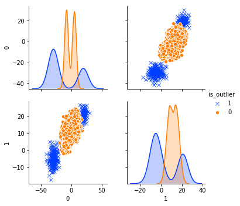

```python
labeled_data = data_features.copy()
labeled_data['is_outlier'] = xgbod_outliers

sns.pairplot(data=labeled_data, vars = other_features,
             hue='is_outlier', hue_order=[1, 0],
             markers=['x', 'o'],  palette='bright');
```

```
Процент выбросов: Original - 3.0 %;                           XGBOD - 3.00 %
```

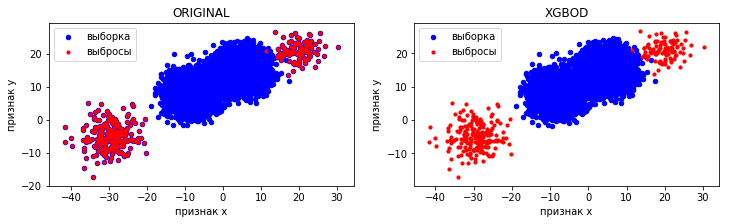

```python
vizualisation_methods(labeled_data, name_method ='XGBOD')
```

# Algorithm Comparison

```python
summary = np.concatenate((
#Statistical
    [std_outliers],
    [iqr_outliers],
#    [euclidian_outliers],
#    [cityblock_outliers],

#Scikit_learn
    [density_outlier],
    [svm_outliers],
    [isolation_outliers],
    [local_factor_outliers],
    [elliptic_envelope_outliers],
    [knn_outliers],

    #PyOD
    [cluster_based_lof_outliers],
    [histogram_base_outliers],
    [autoencoder_outliers]

))

summary = pd.DataFrame(
    summary.T,
#    columns=['std', 'iqr', 'euclid', 'cityblock', 'dbscan', 'svm', 'isolation']
    columns=['std', 'iqr',  'dbscan', 'svm', 'isolation', 'lof', 'elliptic', 'knn', 'cblo', 'histogram', 'autoencoder']
)
print('The result of determining outliers by sample number for each model')
summary.head()
```

[output not shown]

|  | std | iqr | dbscan | svm | isolation | lof | elliptic | knn | cblo | histogram | autoencoder |
| --- | --- | --- | --- | --- | --- | --- | --- | --- | --- | --- | --- |
| 0 | 0 | 0 | 0 | 0 | 1 | 1 | 0 | 0 | 1 | 1 | 1 |
| 1 | 0 | 0 | 0 | 1 | 1 | 1 | 0 | 1 | 1 | 1 | 1 |
| 2 | 0 | 0 | 0 | 0 | 0 | 0 | 0 | 0 | 0 | 0 | 0 |
| 3 | 1 | 0 | 1 | 1 | 1 | 1 | 1 | 1 | 1 | 1 | 1 |
| 4 | 0 | 0 | 0 | 1 | 1 | 1 | 0 | 1 | 1 | 1 | 1 |

```python
#Number of calculated outliers: "0" - no outliers for 9509 cases for all models, "1" outlier - for 88 cases, ....
summary.sum(axis=1).value_counts()
```

```
0     9509
7       95
1       88
2       65
10      57
8       47
9       38
6       35
5       32
4       22
3       10
11       2
dtype: int64
```

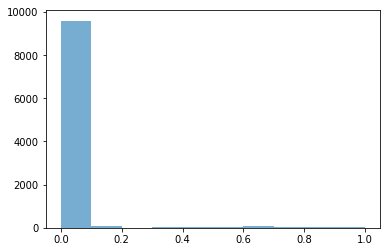

```python
outlier_score = summary.mean(axis=1)
plt.hist(outlier_score, alpha=0.6);
```

# Combination of algorithms

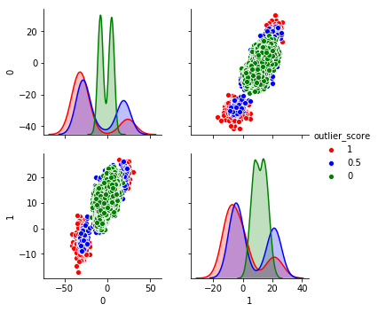

```python
simple_score = outlier_score.apply(lambda x: 0 if x < 0.4 else 0.5 if x < 0.8 else 1)

labeled_data = data_features.copy()
labeled_data['outlier_score'] = simple_score

custom_palette = {0:'g', 0.5:'b', 1.0:'r'}

sns.pairplot(data=labeled_data, vars=other_features,
             hue='outlier_score',
             hue_order=[1, 0.5, 0],
             palette=custom_palette
)
```

```python
def vizualisation_methods_2(labeled_data, name_method):

    fig, ax = plt.subplots(figsize=(12,3), nrows=1, ncols=2)

#Original
    plt.subplot(121)
    ax = fig.add_subplot(121)
    plt.scatter(X[:,0], X[:,1], c='#0000FF',s=20, label='выборка')
    plt.scatter(X[:n_out,0], X[:n_out,1], c='#FF0000', s=10, label='выбросы')
    plt.xlabel('признак x')
    plt.ylabel('признак y')
    plt.title('ORIGINAL')
    plt.legend()

    plt.subplot(122)
    ax = fig.add_subplot(122)
    plt.scatter(labeled_data.iloc[:,0][labeled_data['outlier_score'] == False],
            labeled_data.iloc[:,1][labeled_data['outlier_score'] == False], c='#0000FF',s=20, label='выборка')
    plt.scatter(labeled_data.iloc[:,0][labeled_data['outlier_score'] == 0.5],
            labeled_data.iloc[:,1][labeled_data['outlier_score'] == 0.5], c='#00FF00',s=10, label='???')
    plt.scatter(labeled_data.iloc[:,0][labeled_data['outlier_score'] == True],
            labeled_data.iloc[:,1][labeled_data['outlier_score'] == True], c='#FF0000', s=10, label='выбросы')
    plt.xlabel('признак x')
    plt.ylabel('признак y')
    plt.title(name_method)
    plt.legend()
    print(f"Процент выбросов: Original - {contamination*100} %;                   {name_method}  {100*len(labeled_data.iloc[:,0][labeled_data['outlier_score'] == 1])/len(data):4.2f} %")
```

```
Процент выбросов: Original - 3.0 %;                   Combination of models (only red):  0.97 %
```

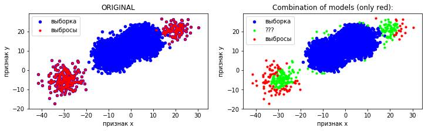

```python
vizualisation_methods_2(labeled_data, 'Combination of models (only red):')
```

# Just model based

```
0    9539
3     138
1     132
4      82
5      78
2      31
dtype: int64
```

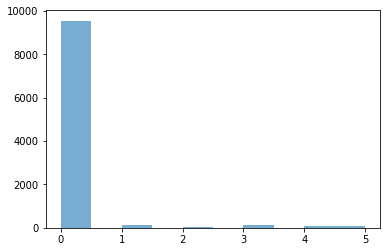

```python
outliers_score_model_based = summary[['dbscan', 'svm', 'isolation', 'lof', 'histogram']].sum(axis=1)
plt.hist(outliers_score_model_based, alpha=0.6);
outliers_score_model_based.value_counts()
```

```
Процент выбросов - без 'green': 4.61 %
```

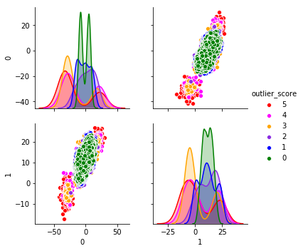

```python
labeled_data = data_features.copy()
labeled_data['outlier_score'] = outliers_score_model_based

custom_palette = {0:'g', 1:'b', 2:'BlueViolet', 3:'orange', 4:'magenta', 5:'red'}

sns.pairplot(data=labeled_data, vars=other_features,
             hue='outlier_score',
             hue_order=[5, 4, 3, 2, 1, 0],
             palette=custom_palette
)
print(f"Процент выбросов - без 'green': {len(labeled_data[labeled_data.outlier_score.isin([1,2,3,4,5])])*100/len(data):4.2f} %" )
```

```python
def vizualisation_methods_3(labeled_data, name_method):
# выбросы - КРАСНЫЕ
    fig, ax = plt.subplots(figsize=(12,3), nrows=1, ncols=2)

#Original
    plt.subplot(121)
    ax = fig.add_subplot(121)
    plt.scatter(X[:,0], X[:,1], c='#0000FF',s=20, label='выборка')
    plt.scatter(X[:n_out,0], X[:n_out,1], c='#FF0000', s=10, label='выбросы')
    plt.xlabel('признак x')
    plt.ylabel('признак y')
    plt.title('ORIGINAL')
    plt.legend()

    plt.subplot(122)
    ax = fig.add_subplot(122)

    plt.scatter(labeled_data.iloc[:,0][labeled_data['outlier_score'] == 0],
            labeled_data.iloc[:,1][labeled_data['outlier_score'] == 0], c='g',s=20, label='выборка')

    plt.scatter(labeled_data.iloc[:,0][labeled_data['outlier_score'] == 1],
            labeled_data.iloc[:,1][labeled_data['outlier_score'] == 1], c='b',s=10, label='q_0.2')

    plt.scatter(labeled_data.iloc[:,0][labeled_data['outlier_score'] == 2],
            labeled_data.iloc[:,1][labeled_data['outlier_score'] == 2], c='BlueViolet', s=10, label='q_0.4')

    plt.scatter(labeled_data.iloc[:,0][labeled_data['outlier_score'] == 3],
            labeled_data.iloc[:,1][labeled_data['outlier_score'] == 3], c='orange',s=10, label='q_0.6')

    plt.scatter(labeled_data.iloc[:,0][labeled_data['outlier_score'] == 4],
            labeled_data.iloc[:,1][labeled_data['outlier_score'] == 4], c='magenta', s=10, label='q_0.8')

    plt.scatter(labeled_data.iloc[:,0][labeled_data['outlier_score'] == 5],
            labeled_data.iloc[:,1][labeled_data['outlier_score'] == 5], c='r', s=10, label='q_1.0')

    plt.xlabel('признак x')
    plt.ylabel('признак y')
    plt.title(name_method)
    plt.legend()
    print(f"Процент выбросов: Original - {contamination*100} %;                   {name_method}  {100*len(labeled_data.iloc[:,0][labeled_data['outlier_score'] !=0])/len(data):4.2f} %")
```

```
Процент выбросов: Original - 3.0 %;                   Combination of models (without green)  4.61 %
```

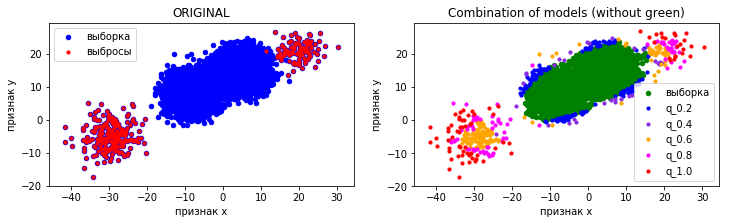

```python
vizualisation_methods_3(labeled_data, 'Combination of models (without green)')
```

#### Sample without explicit outliers

```
Процент выбросов: 1.60 %
```

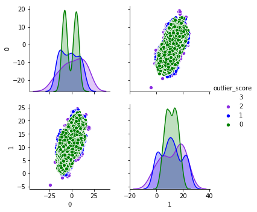

```python
sns.pairplot(data=labeled_data[labeled_data.outlier_score!=3],
             vars=other_features,
             hue='outlier_score',
             hue_order=[3, 2, 1, 0],
             palette=custom_palette
)
print(f"Процент выбросов: {100 - len(labeled_data[labeled_data.outlier_score.isin([0,1,2,3])])*100/len(data):4.2f} %" )
```

```python
def vizualisation_methods_4(labeled_data, name_method):

    fig, ax = plt.subplots(figsize=(12,3), nrows=1, ncols=2)

#Original
    plt.subplot(121)
    ax = fig.add_subplot(121)
    plt.scatter(X[:,0], X[:,1], c='#0000FF',s=20, label='выборка')
    plt.scatter(X[:n_out,0], X[:n_out,1], c='#FF0000', s=10, label='выбросы')
    plt.xlabel('признак x')
    plt.ylabel('признак y')
    plt.title('ORIGINAL')
    plt.legend()

    plt.subplot(122)
    ax = fig.add_subplot(122)

    plt.scatter(labeled_data.iloc[:,0][labeled_data['outlier_score'] == 0],
            labeled_data.iloc[:,1][labeled_data['outlier_score'] == 0], c='g',s=20, label='выборка')

    plt.scatter(labeled_data.iloc[:,0][labeled_data['outlier_score'] == 1],
            labeled_data.iloc[:,1][labeled_data['outlier_score'] == 1], c='b',s=10, label='q_0.2')

    plt.scatter(labeled_data.iloc[:,0][labeled_data['outlier_score'] == 2],
            labeled_data.iloc[:,1][labeled_data['outlier_score'] == 2], c='BlueViolet', s=10, label='q_0.4')

    plt.scatter(labeled_data.iloc[:,0][labeled_data['outlier_score'] == 3],
            labeled_data.iloc[:,1][labeled_data['outlier_score'] == 3], c='orange',s=10, label='q_0.6')


    plt.xlabel('признак x')
    plt.ylabel('признак y')
    plt.title(name_method)
    plt.legend()
    print(f"Процент выбросов: Original - {contamination*100} %;                   {name_method}  {100 - len(labeled_data[labeled_data.outlier_score.isin([0,1,2,3])])*100/len(data):4.2f} %")
```

```
Процент выбросов: Original - 3.0 %;                   Combination of models (without red_5+magenta_4)  1.60 %
```

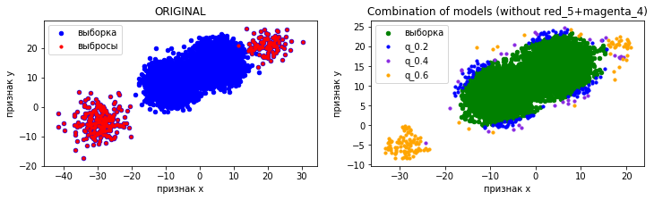

```python
vizualisation_methods_4(labeled_data, 'Combination of models (without red_5+magenta_4)')
```

#### High Probability Sampling of Real Data

```
Процент выбросов: 3.29 %
```

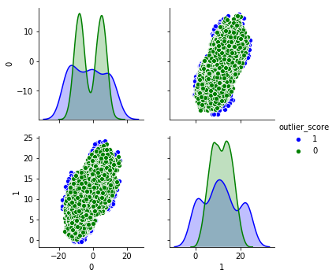

```python
sns.pairplot(data=labeled_data[labeled_data.outlier_score.isin([0, 1])],
             vars=other_features,
             hue='outlier_score',
             hue_order=[1, 0],
             palette=custom_palette
)
print(f"Процент выбросов: {100 - len(labeled_data[labeled_data.outlier_score.isin([0,1])])*100/len(data):4.2f} %" )
```

```python
def vizualisation_methods_5(labeled_data, name_method):
    fig, ax = plt.subplots(figsize=(12,3), nrows=1, ncols=2)

#Original
    plt.subplot(121)
    ax = fig.add_subplot(121)
    plt.scatter(X[:,0], X[:,1], c='#0000FF',s=20, label='выборка')
    plt.scatter(X[:n_out,0], X[:n_out,1], c='#FF0000', s=10, label='выбросы')
    plt.xlabel('признак x')
    plt.ylabel('признак y')
    plt.title('ORIGINAL')
    plt.legend()

    plt.subplot(122)
    ax = fig.add_subplot(122)

    plt.scatter(labeled_data.iloc[:,0][labeled_data['outlier_score'] == 0],
            labeled_data.iloc[:,1][labeled_data['outlier_score'] == 0], c='g',s=20, label='выборка')

    plt.scatter(labeled_data.iloc[:,0][labeled_data['outlier_score'] == 1],
            labeled_data.iloc[:,1][labeled_data['outlier_score'] == 1], c='b',s=10, label='q_0.2')

    plt.xlabel('признак x')
    plt.ylabel('признак y')
    plt.title(name_method)
    plt.legend()
    print(f"Процент выбросов: Original - {contamination*100} %;         {name_method}  {100 - len(labeled_data[labeled_data.outlier_score.isin([0,1])])*100/len(data):4.2f} %")
```

```
Процент выбросов: Original - 3.0 %;         Combination of models (without: red_5+magenta_4+orange_3+BlueViolet_2)  3.29 %
```

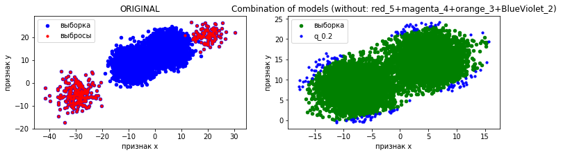

```python
vizualisation_methods_5(labeled_data, 'Combination of models (without: red_5+magenta_4+orange_3+BlueViolet_2)')
```

#### Data WITHOUT outliers

```
Процент выбросов: 4.61 %
```

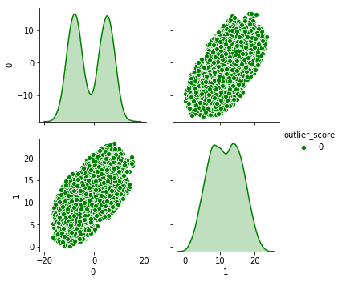

```python
sns.pairplot(data=labeled_data[labeled_data.outlier_score.isin([0])],
             vars=other_features,
             hue='outlier_score',
             hue_order=[0],
             palette=custom_palette
)
print(f"Процент выбросов: {100 - len(labeled_data[labeled_data.outlier_score.isin([0])])*100/len(data):4.2f} %" )
```

```python
def vizualisation_methods_6(labeled_data, name_method):
    fig, ax = plt.subplots(figsize=(12,3), nrows=1, ncols=2)

#Original
    plt.subplot(121)
    ax = fig.add_subplot(121)
    plt.scatter(X[:,0], X[:,1], c='#0000FF',s=20, label='выборка')
    plt.scatter(X[:n_out,0], X[:n_out,1], c='#FF0000', s=10, label='выбросы')
    plt.xlabel('признак x')
    plt.ylabel('признак y')
    plt.title('ORIGINAL')
    plt.legend()

    plt.subplot(122)
    ax = fig.add_subplot(122)

    plt.scatter(labeled_data.iloc[:,0][labeled_data['outlier_score'] == 0],
            labeled_data.iloc[:,1][labeled_data['outlier_score'] == 0], c='g',s=20, label='выборка')


    plt.xlabel('признак x')
    plt.ylabel('признак y')
    plt.title(name_method)
    plt.legend()
    print(f"Процент выбросов: Original - {contamination*100} %;         {name_method}  {100 - len(labeled_data[labeled_data.outlier_score.isin([0])])*100/len(data):4.2f} %")
```

```
Процент выбросов: Original - 3.0 %;         Combination of models (only green)  4.61 %
```

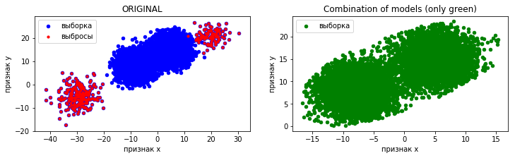

```python
vizualisation_methods_6(labeled_data, 'Combination of models (only green)')
```

#### f1_score

```python
std_outliers_ = np.array(std_outliers.apply(lambda x: 0 if x ==False else 1))
iqr_outliers_ = np.array(iqr_outliers.apply(lambda x: 0 if x ==False else 1))
summary_outlier_array = (std_outliers_, iqr_outliers_, density_outlier, svm_outliers, isolation_outliers, local_factor_outliers,
                        elliptic_envelope_outliers, knn_outliers, cluster_based_lof_outliers, histogram_base_outliers, autoencoder_outliers)
k=0
for i in summary_outlier_array:
    print(f" {k+1}) f1_score: {summary.columns[k]} = {f1_score(y, i, average='macro'):6.4f}")
    k+=1
```

```
 1) f1_score: std = 0.8837
 2) f1_score: iqr = 0.4991
 3) f1_score: dbscan = 0.7363
 4) f1_score: svm = 0.7311
 5) f1_score: isolation = 0.9845
 6) f1_score: lof = 0.9777
 7) f1_score: elliptic = 0.8471
 8) f1_score: knn = 0.8157
 9) f1_score: cblo = 0.9828
 10) f1_score: histogram = 0.9715
 11) f1_score: autoencoder = 0.9828
```

# Formation TRAIN & TEST

```python
# Разбиение на TRAIN & TEST
df = pd.DataFrame(X)
df['y'] =y
df = shuffle(df, random_state=42)
train, test = train_test_split(df, test_size=n_test_size, random_state=1)
```

```
traine_outlier: 2.97 %
test_outlier:   3.07 %
```

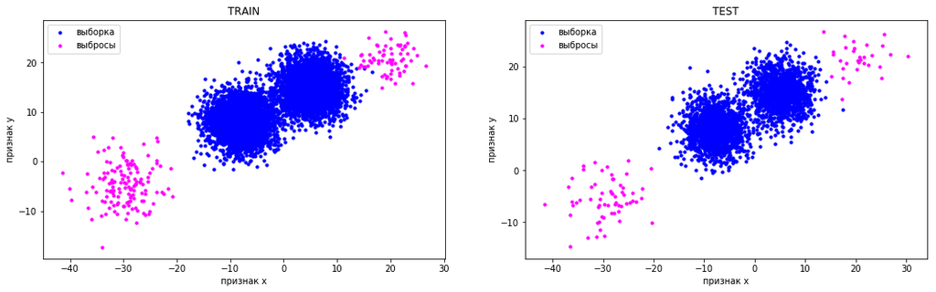

```python
fig, ax = plt.subplots(figsize=(18,5), nrows=1, ncols=2)
# Посмoтрим выбросы - КРАСНЫЕ

#Трейновая выборка
train_in = train[train.y==0.0]
train_out = train[train.y==1.0]
plt.subplot(121)
ax = fig.add_subplot(121)
plt.scatter(train_in.iloc[:,0], train_in.iloc[:,1], c='#0000FF', s = 10, label='выборка')
plt.scatter(train_out.iloc[:,0], train_out.iloc[:,1], c='#FF00FF', s = 10, label='выбросы')
plt.xlabel('признак x')
plt.ylabel('признак y')
plt.title('TRAIN')
plt.legend()

#Тестовая выборка
test_in = test[test.y==0.0]
test_out = test[test.y==1.0]
plt.subplot(122)
ax = fig.add_subplot(122)
plt.scatter(test_in.iloc[:,0], test_in.iloc[:,1], c='#0000FF', s = 10, label='выборка')
plt.scatter(test_out.iloc[:,0], test_out.iloc[:,1], c='#FF00FF', s = 10, label='выбросы')
plt.xlabel('признак x')
plt.ylabel('признак y')
plt.title('TEST')
plt.legend()

print(f"traine_outlier: {len(train[train.y==1])*100/len(train):4.2f} %")
print(f"test_outlier:   {len(test[test.y==1])*100/len(test):4.2f} % ")
```

```python
X_train = train.iloc[:,:-1].copy()
y_train = train.iloc[:,2].copy()

X_test = test.iloc[:,:-1].copy()
y_test= test.iloc[:,2].copy()
X_train.index = np.arange(len(X_train))
X_test.index = np.arange(len(X_test))
```

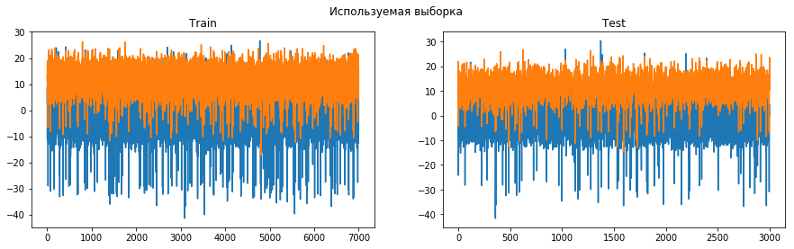

```python
fig, (ax1, ax2) = plt.subplots(1, 2, figsize=(15,4))
fig.suptitle('Используемая выборка')
ax1.set_title('Train')
ax1.plot(X_train.iloc[:, :])
ax2.set_title('Test')
ax2.plot(X_test.iloc[:, :])

#X_test.iloc[:, :].plot(legend=None, title='X_test')
```

### TRAIN and TEST data preparation

```python
# scaler
scaler = RobustScaler()

data_X_train = pd.DataFrame(X_train)
data_X_train.columns =['0', '1']

data_X_test = pd.DataFrame(X_test)
data_X_test.columns =['0', '1']

data_features_train = X_train.iloc[:, :]
data_features_test = X_test.iloc[:, :]

scaled_data_train = pd.DataFrame(
    data=scaler.fit_transform(data_features_train),
    columns=data_features_train.columns
)
scaled_data_test = pd.DataFrame(
    data=scaler.fit_transform(data_features_test),
    columns=data_features_test.columns
)
```

```python
def vizualisation_methods_test(test, labeled_data_test, name_method):
# выбросы - КРАСНЫЕ
    fig, ax = plt.subplots(figsize=(12,3), nrows=1, ncols=2)

#Тестовая выборка Original
    test_in = test[test.y==0.0]
    test_out = test[test.y==1.0]
    plt.subplot(121)
    ax = fig.add_subplot(121)
    plt.scatter(test_in.iloc[:,0], test_in.iloc[:,1], c='#0000FF', s = 10, label='выборка')
    plt.scatter(test_out.iloc[:,0], test_out.iloc[:,1], c='#FF00FF', s = 10, label='выбросы')
    plt.xlabel('признак x')
    plt.ylabel('признак y')
    plt.title('TEST Original')
    plt.legend()

    plt.subplot(122)
    ax = fig.add_subplot(122)
    plt.scatter(labeled_data_test.iloc[:,0][labeled_data_test['is_outlier'] == False],
            labeled_data_test.iloc[:,1][labeled_data_test['is_outlier'] == False], c='#0000FF',s=10, label='выборка')

    plt.scatter(labeled_data_test.iloc[:,0][labeled_data_test['is_outlier'] == True],
            labeled_data_test.iloc[:,1][labeled_data_test['is_outlier'] == True], c='#FF0000', s=10, label='выбросы')
    plt.xlabel('признак x')
    plt.ylabel('признак y')
    plt.title(name_method)
    plt.legend()
    print(f"Процент выбросов: Original TEST - {contamination*100} %;                           {name_method} - {100 - 100*len(labeled_data_test.iloc[:,0][labeled_data_test['is_outlier'] == False])/len(test):4.2f} %")
```

### KNN

```python
#n_neighbors = 1
knn = KNN(contamination = contamination)
knn.fit(scaled_data_train)
#knn_outliers = knn.labels_
knn_outliers_train = knn.predict(scaled_data_train)
knn_outliers_train = np.array([1 if label == 1 else 0 for label in knn_outliers_train])
anomalies_report(knn_outliers_train)
print(f"f1_score_for_Train:  {f1_score(y_train, knn_outliers_train, average='macro'):6.4f}")
```

```
Total number of outliers: 162
Percentage of outliers:           2.31%
f1_score_for_Train:  0.7890
```

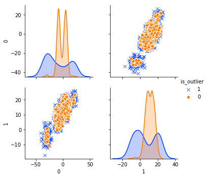

```python
other_features_train = [col for col in data_X_train.columns]
labeled_data_train = data_features_train
labeled_data_train['is_outlier'] = knn_outliers_train

sns.pairplot(data=labeled_data_train, vars = other_features_train,
             hue='is_outlier', hue_order=[1, 0],
             markers=['x', 'o'],  palette='bright');
```

```python
#knn.fit(scaled_data_test)
knn_outliers_test = knn.predict(scaled_data_test)
knn_outliers_test = np.array([1 if label == 1 else 0 for label in knn_outliers_test])
anomalies_report(knn_outliers_test)
print(f"f1_score_for_Test:  {f1_score(y_test, knn_outliers_test, average='macro'):6.4f}")
```

```
Total number of outliers: 96
Percentage of outliers:           3.20%
f1_score_for_Test:  0.8408
```

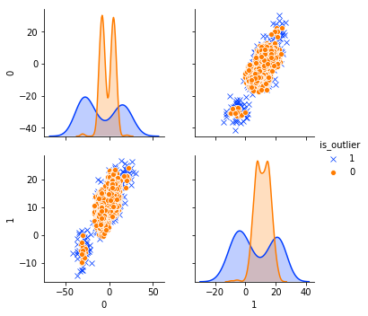

```python
other_features_test = [col for col in data_X_test.columns]
labeled_data_test = data_features_test.copy()
labeled_data_test['is_outlier'] = knn_outliers_test

sns.pairplot(data=labeled_data_test, vars = other_features_test,
             hue='is_outlier', hue_order=[1, 0],
             markers=['x', 'o'],  palette='bright');
```

```
Процент выбросов: Original TEST - 3.0 %;                           KNN - for Test - 3.20 %
```

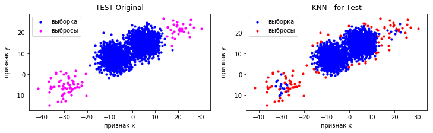

```python
vizualisation_methods_test(test, labeled_data_test, 'KNN - for Test')
```

### IsolationForest

```python
isolation_forest = IsolationForest(n_estimators=10, contamination=contamination,
                                   max_features=1.0, bootstrap=True, behaviour="new")
isolation_forest.fit(scaled_data_train)

isolation_outliers_train = isolation_forest.predict(scaled_data_train)
isolation_outliers_train = np.array([1 if label == -1 else 0 for label in isolation_outliers_train])

anomalies_report(isolation_outliers_train)
print(f"f1_score_for_Train:  {f1_score(y_train, isolation_outliers_train, average='macro'):6.4f}")
```

```
Total number of outliers: 210
Percentage of outliers:           3.00%
f1_score_for_Train:  0.9605
```

```python
#isolation_forest.fit(scaled_data_test)
isolation_outliers_test = isolation_forest.predict(scaled_data_test)
isolation_outliers_test = np.array([1 if label == -1 else 0 for label in isolation_outliers_test])
anomalies_report(isolation_outliers_test)
print(f"f1_score_for_Test:  {f1_score(y_test, isolation_outliers_test, average='macro'):6.4f}")
```

```
Total number of outliers: 94
Percentage of outliers:           3.13%
f1_score_for_Test:  0.9723
```

```
Процент выбросов: Original TEST - 3.0 %;                           IsolationForest - for Test - 3.13 %
```

[figure not shown]

```python
labeled_data_test['is_outlier'] = isolation_outliers_test
vizualisation_methods_test(test, labeled_data_test, 'IsolationForest - for Test')
```

```python
from sklearn.manifold import TSNE
tsne = TSNE(verbose=1,n_iter=5000)
res = tsne.fit_transform(scaled_data_train)
```

[output not shown]

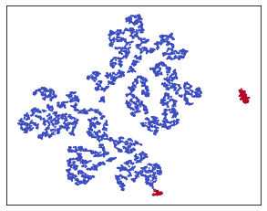

```python
fig = plt.figure(figsize=(5,4))
scatter =plt.scatter(res[:,0],res[:,1],c=y_train, cmap='coolwarm', s=0.6)
scatter.axes.get_xaxis().set_visible(False)
scatter.axes.get_yaxis().set_visible(False)
```

### LocalOutlierFactor

```python
local_outlier_factor = LocalOutlierFactor( n_neighbors=200, contamination=contamination, novelty=False)
local_outlier_factor.fit(scaled_data_train)

local_factor_outliers_train = local_outlier_factor.fit_predict(scaled_data_train)
local_factor_outliers_train = np.array([1 if label == -1 else 0 for label in local_factor_outliers_train])

anomalies_report(local_factor_outliers_train)
print(f"f1_score_for_Train:  {f1_score(y_train, local_factor_outliers_train, average='macro'):6.4f}")
```

```
Total number of outliers: 210
Percentage of outliers:           3.00%
f1_score_for_Train:  0.9729
```

```python
#local_outlier_factor.fit(scaled_data_test)
local_factor_outliers_test = local_outlier_factor.fit_predict(scaled_data_test)
local_factor_outliers_test = np.array([1 if label == -1 else 0 for label in local_factor_outliers_test])
anomalies_report(local_factor_outliers_test)
print(f"f1_score_for_Test:  {f1_score(y_test, local_factor_outliers_test, average='macro'):6.4f}")
```

```
Total number of outliers: 90
Percentage of outliers:           3.00%
f1_score_for_Test:  0.9830
```

```
Процент выбросов: Original TEST - 3.0 %;                           LocalOutlierFactor - for Test - 3.00 %
```

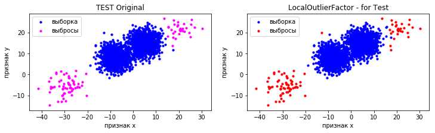

```python
labeled_data_test['is_outlier'] = local_factor_outliers_test
vizualisation_methods_test(test, labeled_data_test, 'LocalOutlierFactor - for Test')
```

### OneClassSVM

```python
one_class_svm = OneClassSVM(nu=contamination, gamma='auto')
one_class_svm.fit(scaled_data_train)
svm_outliers_train = one_class_svm.predict(scaled_data_train)
svm_outliers_train = np.array([1 if label == -1 else 0 for label in svm_outliers_train])
anomalies_report(svm_outliers_train)
print(f"f1_score_for_Train:  {f1_score(y_train, svm_outliers_train, average='macro'):6.4f}")
```

```
Total number of outliers: 211
Percentage of outliers:           3.01%
f1_score_for_Train:  0.7306
```

```python
one_class_svm_outliers_test = one_class_svm.predict(scaled_data_test)
one_class_svm_outliers_test = np.array([1 if label == -1 else 0 for label in one_class_svm_outliers_test])
anomalies_report(one_class_svm_outliers_test)
print(f"f1_score_for_Test:  {f1_score(y_test, one_class_svm_outliers_test, average='macro'):6.4f}")
```

```
Total number of outliers: 79
Percentage of outliers:           2.63%
f1_score_for_Test:  0.7502
```

```
Процент выбросов: Original TEST - 3.0 %;                           OneClassSVM - for Test - 2.63 %
```

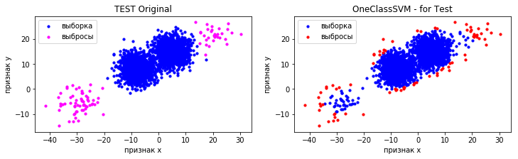

```python
labeled_data_test['is_outlier'] = one_class_svm_outliers_test
vizualisation_methods_test(test, labeled_data_test, 'OneClassSVM - for Test')
```

### CBLOF

```python
cluster_based_lof = CBLOF(contamination=contamination, check_estimator=False, random_state=42)
cluster_based_lof.fit(scaled_data_train)
cblof_outliers_train = cluster_based_lof.predict(scaled_data_train)
cblof_outliers_train = np.array([1 if label == 1 else 0 for label in cblof_outliers_train])
anomalies_report(cblof_outliers_train)
print(f"f1_score_for_Train:  {f1_score(y_train, cblof_outliers_train, average='macro'):6.4f}")
```

```
Total number of outliers: 210
Percentage of outliers:           3.00%
f1_score_for_Train:  0.9803
```

```python
cblof_outliers_test = cluster_based_lof.predict(scaled_data_test)
cblof_outliers_test = np.array([1 if label == 1 else 0 for label in cblof_outliers_test])
anomalies_report(cblof_outliers_test)
print(f"f1_score_for_Test:  {f1_score(y_test, cblof_outliers_test, average='macro'):6.4f}")
```

```
Total number of outliers: 95
Percentage of outliers:           3.17%
f1_score_for_Test:  0.9917
```

```
Процент выбросов: Original TEST - 3.0 %;                           cblof - for Test - 3.17 %
```

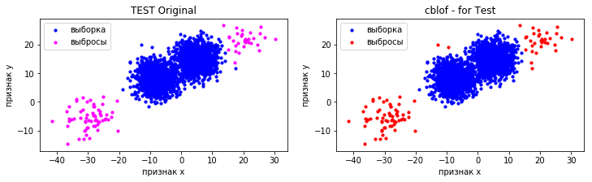

```python
labeled_data_test['is_outlier'] = cblof_outliers_test
vizualisation_methods_test(test, labeled_data_test, 'cblof - for Test')
```

### XGBOD

```python
xgbod = XGBOD(contamination=contamination)
xgbod.fit(scaled_data_train, y_train)

xgbod_outliers_train =xgbod.predict(scaled_data_train)
xgbod_outliers_train = np.array([1 if label == 1 else 0 for label in xgbod_outliers_train])
anomalies_report(xgbod_outliers_train)
print(f"f1_score_for_Train:  {f1_score(y_train, xgbod_outliers_train, average='macro'):6.4f}")
```

```
Total number of outliers: 208
Percentage of outliers:           2.97%
f1_score_for_Train:  1.0000
```

```python
xgbod_outliers_test = xgbod.predict(scaled_data_test)
xgbod_outliers_test = np.array([1 if label == 1 else 0 for label in xgbod_outliers_test])
anomalies_report(xgbod_outliers_test)
print(f"f1_score_for_Test:  {f1_score(y_test, xgbod_outliers_test, average='macro'):6.4f}")
```

```
Total number of outliers: 94
Percentage of outliers:           3.13%
f1_score_for_Test:  0.9834
```

```
Процент выбросов: Original TEST - 3.0 %;                           cblof - for Test - 3.13 %
```

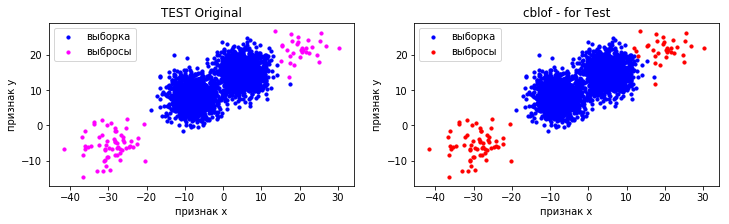

```python
labeled_data_test['is_outlier'] = xgbod_outliers_test
vizualisation_methods_test(test, labeled_data_test, 'cblof - for Test')
```